# Data Analysis and Prediction for Life Expectancy

Group 106: Artsiom Strok, Lin Jiang, Mayank Chhablani

July 15, 2019

## Introduction

Life expectancy has increased dramatically over the last few centuries. Since 1900 the global average life expectancy has more than doubled and there has been a huge development in health sector in the past 15 years resulting in improvement of human mortality rates especially in the developing nations in comparison to the past 30 years. Therefore, in this project, only data from year 2000-2015 is considered for exploration and analysis.

This dataset is a compilation of data from the Global Health Observatory (GHO) and United Nations. The GHO data repository is WHO’s gateway to health-related statistics which provides access to a variety of indicators on priority health topics including mortality and burden of diseases, environmental health, violence and injuries etc. (http://apps.who.int/gho/data/node.resources). The economic data such as GDP is collected from the National Accounts Main Aggregates Database under United Nations which collects and disseminates economic statistics from countries worldwide (https://unstats.un.org/unsd/snaama/Index).

This dataset is cleaned by removing some missing values, maily for population, Hepatitis B and GDP from less known countries and shared on Kaggle website (https://www.kaggle.com/kumarajarshi/life-expectancy-who). The final dataset contains 2938 observations with 22 variables which are more critical and representative among all the categories of health-related factors from year 2000 - 2015 for 193 countries.

The description of each variable for this dataset is listed below:

- **Country**: Country
- **Year**: Year
- **Status**: Developed or Developing status
- **Life expectancy**: Life Expectancy in age
- **Adult Mortality**: Adult Mortality Rates of both sexes (probability of dying between 15 and 60 years per 1000 population)
- **infant**: deathsNumber of Infant Deaths per 1000 population
- **Alcohol**: Alcohol, recorded per capita (15+) consumption (in litres of pure alcohol)
- **percentage expenditure**: Expenditure on health as a percentage of Gross Domestic Product per capita(%)
- **Hepatitis B**: Hepatitis B (HepB) immunization coverage among 1-year-olds (%)
- **Measles**: Measles - number of reported cases per 1000 population
- **BMI**: Average Body Mass Index of entire population
- **under-five deaths**: Number of under-five deaths per 1000 population
- **Polio**: Polio (Pol3) immunization coverage among 1-year-olds (%)
- **Total expenditure**: General government expenditure on health as a percentage of total government expenditure (%)
- **Diphtheria**: Diphtheria tetanus toxoid and pertussis (DTP3) immunization coverage among 1-year-olds (%)
- **HIV/AIDS**: Deaths per 1 000 live births HIV/AIDS (0-4 years)
- **GDP**: Gross Domestic Product per capita (in USD)
- **Population**: Population of the country
- **thinness 1-19 years**: Prevalence of thinness among children and adolescents for Age 10 to 19 (% )
- **thinness 5-9 years**: Prevalence of thinness among children for Age 5 to 9(%)
- **Income composition of resources**: Human Development Index in terms of income composition of resources (index ranging from 0 to 1)
- **Schooling**: Number of years of Schooling(years)

For this project, we would like to:

- identify the major factors that affect the life expectancy
- explore the interactions between the variables such as immunization, moratlity, education, economic factors etc.
- discover the corelation between different factors
- perform residual and outlier diagnostics to exclude some influential points if any
- build a robust multiple linear regression model to predict the life expectancy
- build a classifier to estimate the status of a country (developing or developed)

## Methods

### Missing values analysis:

```r
original_data = read.csv("Life Expectancy Data.csv")
kable(t(original_data[sample(nrow(original_data), 5), ]))
```

|  | 2733 | 1625 | 1759 | 2719 | 2021 |
| --- | --- | --- | --- | --- | --- |
| Country | Ukraine | Mali | Morocco | Uganda | Peru |
| Year | 2013 | 2009 | 2005 | 2011 | 2002 |
| Status | Developing | Developing | Developing | Developing | Developing |
| Life.expectancy | 71.0 | 56.0 | 77.0 | 59.3 | 72.6 |
| Adult.Mortality | 198 | 276 | 137 | 347 | 144 |
| infant.deaths | 4 | 55 | 22 | 76 | 16 |
| Alcohol | 8.44 | 0.59 | 0.47 | 10.22 | 4.03 |
| percentage.expenditure | 52.425 | 84.634 | 9.469 | 94.497 | 40.538 |
| Hepatitis.B | 46 | 71 | 96 | 82 | NA |
| Measles | 0 | 2939 | 0 | 3312 | 0 |
| BMI | 6.1 | 2.2 | 49.1 | 16.7 | 46.7 |
| under.five.deaths | 5 | 93 | 26 | 114 | 20 |
| Polio | 72 | 77 | 98 | 82 | 95 |
| Total.expenditure | 7.67 | 6.85 | 5.60 | 9.90 | 4.94 |
| Diphtheria | 76 | 73 | 98 | 82 | 95 |
| HIV.AIDS | 0.2 | 1.6 | 0.1 | 6.8 | 0.4 |
| GDP | 429.7 | 697.2 | 213.8 | 584.4 | 259.2 |
| Population | 454896 | 1466597 | 35217 | 3593648 | 2661467 |
| thinness..1.19.years | 2.3 | 9.0 | 6.5 | 5.9 | 1.4 |
| thinness.5.9.years | 2.4 | 8.8 | 6.3 | 5.9 | 1.4 |
| Income.composition.of.resources | 0.744 | 0.385 | 0.569 | 0.477 | 0.686 |
| Schooling | 15.2 | 7.1 | 9.8 | 10.7 | 13.9 |

```r
kable(colSums(is.na(original_data)), col.names = "Number of missing values")
```

|  | Number of missing values |
| --- | --- |
| Country | 0 |
| Year | 0 |
| Status | 0 |
| Life.expectancy | 10 |
| Adult.Mortality | 10 |
| infant.deaths | 0 |
| Alcohol | 194 |
| percentage.expenditure | 0 |
| Hepatitis.B | 553 |
| Measles | 0 |
| BMI | 34 |
| under.five.deaths | 0 |
| Polio | 19 |
| Total.expenditure | 226 |
| Diphtheria | 19 |
| HIV.AIDS | 0 |
| GDP | 448 |
| Population | 652 |
| thinness..1.19.years | 34 |
| thinness.5.9.years | 34 |
| Income.composition.of.resources | 167 |
| Schooling | 163 |

Life expextancy and adult mortality is missing for 10 samples in 2013, all of them belongs to islands.

Hepatitis B is missing in 553 samples. Samples belongs to different countries and years.

```r
nrow(original_data)
```

```
## [1] 2938
```

```r
data = na.omit(original_data)
nrow(original_data) - nrow(data)
```

```
## [1] 1289
```

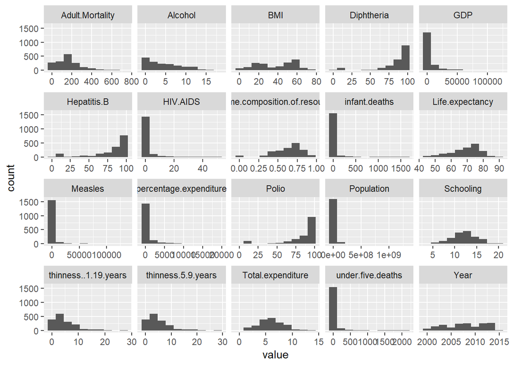

```r
ggplot(gather(data[-c(1, 3)]), aes(value)) +
    geom_histogram(bins = 10) +
    facet_wrap(~key, scales = 'free_x')
```

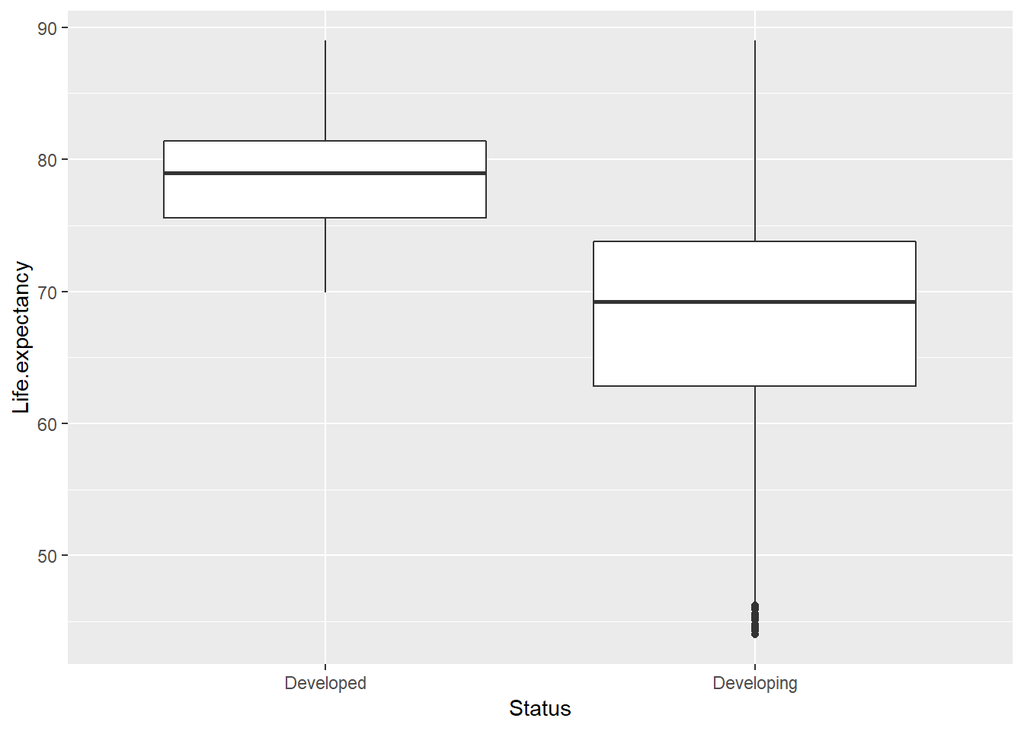

```r
ggplot(data, aes(x = Status, y = Life.expectancy)) + geom_boxplot()
```

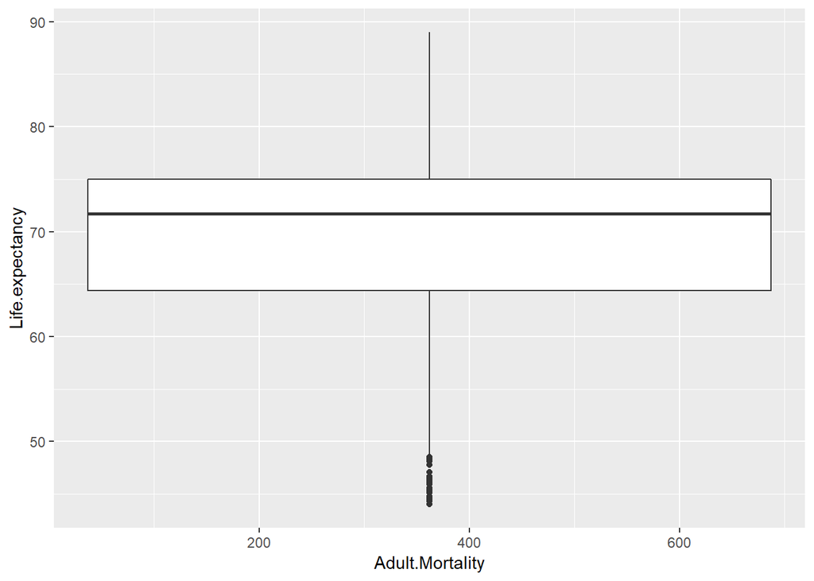

```r
ggplot(data, aes(x = Adult.Mortality, y = Life.expectancy)) + geom_boxplot()
```

This original dataset contains `Country` variable which we would not use for model building. Therefore, this column is excluded from the following data analysis as well as the records with `NA` in some of the columns mentioned above. This will reduce the size of the original dataset from 2938 to 1649 rows, which captures majority of the information and allows the speed of modeling to be more efficient.

Below lists the summary and structure of the cleaned dataset.

```r
summary(data)
```

```
##         Country          Year             Status     Life.expectancy
##  Afghanistan:  16   Min.   :2000   Developed : 242   Min.   :44.0
##  Albania    :  16   1st Qu.:2005   Developing:1407   1st Qu.:64.4
##  Armenia    :  15   Median :2008                     Median :71.7
##  Austria    :  15   Mean   :2008                     Mean   :69.3
##  Belarus    :  15   3rd Qu.:2011                     3rd Qu.:75.0
##  Belgium    :  15   Max.   :2015                     Max.   :89.0
##  (Other)    :1557
##  Adult.Mortality infant.deaths       Alcohol      percentage.expenditure
##  Min.   :  1     Min.   :   0.0   Min.   : 0.01   Min.   :    0
##  1st Qu.: 77     1st Qu.:   1.0   1st Qu.: 0.81   1st Qu.:   37
##  Median :148     Median :   3.0   Median : 3.79   Median :  145
##  Mean   :168     Mean   :  32.6   Mean   : 4.53   Mean   :  699
##  3rd Qu.:227     3rd Qu.:  22.0   3rd Qu.: 7.34   3rd Qu.:  509
##  Max.   :723     Max.   :1600.0   Max.   :17.87   Max.   :18961
##
##   Hepatitis.B      Measles            BMI       under.five.deaths
##  Min.   : 2.0   Min.   :     0   Min.   : 2.0   Min.   :   0.0
##  1st Qu.:74.0   1st Qu.:     0   1st Qu.:19.5   1st Qu.:   1.0
##  Median :89.0   Median :    15   Median :43.7   Median :   4.0
##  Mean   :79.2   Mean   :  2224   Mean   :38.1   Mean   :  44.2
##  3rd Qu.:96.0   3rd Qu.:   373   3rd Qu.:55.8   3rd Qu.:  29.0
##  Max.   :99.0   Max.   :131441   Max.   :77.1   Max.   :2100.0
##
##      Polio      Total.expenditure   Diphtheria      HIV.AIDS
##  Min.   : 3.0   Min.   : 0.74     Min.   : 2.0   Min.   : 0.10
##  1st Qu.:81.0   1st Qu.: 4.41     1st Qu.:82.0   1st Qu.: 0.10
##  Median :93.0   Median : 5.84     Median :92.0   Median : 0.10
##  Mean   :83.6   Mean   : 5.96     Mean   :84.2   Mean   : 1.98
##  3rd Qu.:97.0   3rd Qu.: 7.47     3rd Qu.:97.0   3rd Qu.: 0.70
##  Max.   :99.0   Max.   :14.39     Max.   :99.0   Max.   :50.60
##
##       GDP           Population       thinness..1.19.years thinness.5.9.years
##  Min.   :     2   Min.   :3.40e+01   Min.   : 0.10        Min.   : 0.10
##  1st Qu.:   462   1st Qu.:1.92e+05   1st Qu.: 1.60        1st Qu.: 1.70
##  Median :  1593   Median :1.42e+06   Median : 3.00        Median : 3.20
##  Mean   :  5566   Mean   :1.47e+07   Mean   : 4.85        Mean   : 4.91
##  3rd Qu.:  4719   3rd Qu.:7.66e+06   3rd Qu.: 7.10        3rd Qu.: 7.10
##  Max.   :119173   Max.   :1.29e+09   Max.   :27.20        Max.   :28.20
##
##  Income.composition.of.resources   Schooling
##  Min.   :0.000                   Min.   : 4.2
##  1st Qu.:0.509                   1st Qu.:10.3
##  Median :0.673                   Median :12.3
##  Mean   :0.632                   Mean   :12.1
##  3rd Qu.:0.751                   3rd Qu.:14.0
##  Max.   :0.936                   Max.   :20.7
##
```

```r
data = na.omit(data)
data = data[-1] #exclude country from dataset
str(data)
```

```
## 'data.frame':    1649 obs. of  21 variables:
##  $ Year                           : int  2015 2014 2013 2012 2011 2010 2009 2008 2007 2006 ...
##  $ Status                         : Factor w/ 2 levels "Developed","Developing": 2 2 2 2 2 2 2 2 2 2 ...
##  $ Life.expectancy                : num  65 59.9 59.9 59.5 59.2 58.8 58.6 58.1 57.5 57.3 ...
##  $ Adult.Mortality                : int  263 271 268 272 275 279 281 287 295 295 ...
##  $ infant.deaths                  : int  62 64 66 69 71 74 77 80 82 84 ...
##  $ Alcohol                        : num  0.01 0.01 0.01 0.01 0.01 0.01 0.01 0.03 0.02 0.03 ...
##  $ percentage.expenditure         : num  71.3 73.5 73.2 78.2 7.1 ...
##  $ Hepatitis.B                    : int  65 62 64 67 68 66 63 64 63 64 ...
##  $ Measles                        : int  1154 492 430 2787 3013 1989 2861 1599 1141 1990 ...
##  $ BMI                            : num  19.1 18.6 18.1 17.6 17.2 16.7 16.2 15.7 15.2 14.7 ...
##  $ under.five.deaths              : int  83 86 89 93 97 102 106 110 113 116 ...
##  $ Polio                          : int  6 58 62 67 68 66 63 64 63 58 ...
##  $ Total.expenditure              : num  8.16 8.18 8.13 8.52 7.87 9.2 9.42 8.33 6.73 7.43 ...
##  $ Diphtheria                     : int  65 62 64 67 68 66 63 64 63 58 ...
##  $ HIV.AIDS                       : num  0.1 0.1 0.1 0.1 0.1 0.1 0.1 0.1 0.1 0.1 ...
##  $ GDP                            : num  584.3 612.7 631.7 670 63.5 ...
##  $ Population                     : num  33736494 327582 31731688 3696958 2978599 ...
##  $ thinness..1.19.years           : num  17.2 17.5 17.7 17.9 18.2 18.4 18.6 18.8 19 19.2 ...
##  $ thinness.5.9.years             : num  17.3 17.5 17.7 18 18.2 18.4 18.7 18.9 19.1 19.3 ...
##  $ Income.composition.of.resources: num  0.479 0.476 0.47 0.463 0.454 0.448 0.434 0.433 0.415 0.405 ...
##  $ Schooling                      : num  10.1 10 9.9 9.8 9.5 9.2 8.9 8.7 8.4 8.1 ...
```

### Data Visualization

Let’s take a look of the dataset using plots of `Life Expectancy` vs `Status` or `Year`. The boxplot indicates that there is significant difference in `Life Expectancy` between the `Developed` and `Developing` countries. As expected, the `Life Expectancy` increases as the `Year` passes by and the Violin plot shows that the data is well distributed across different years.

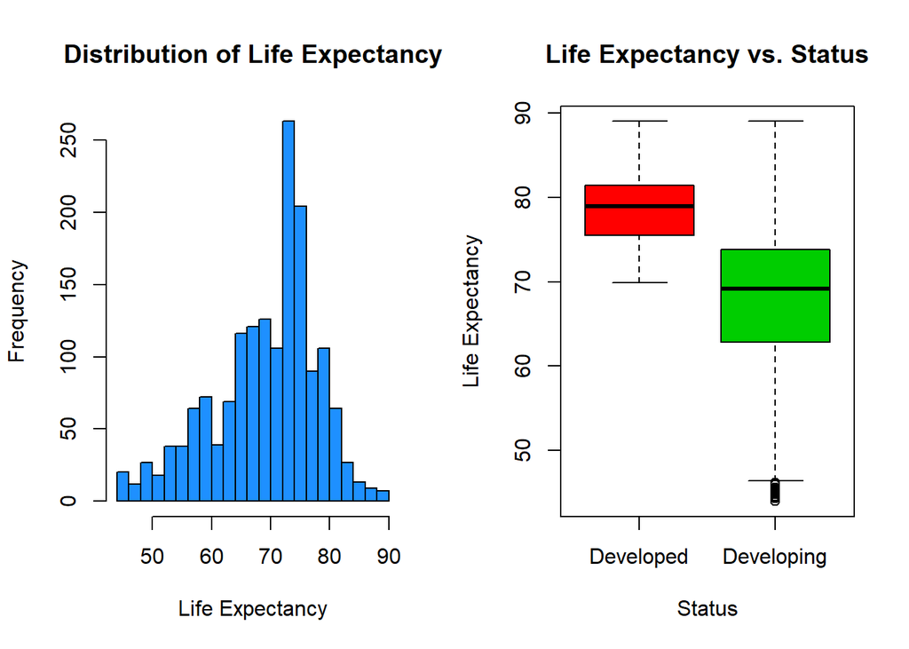

```r
par(mfrow=c(1,2))
# Histogram of Life Expectancy
hist(data$Life.expectancy,
     xlab = "Life Expectancy",
     main = "Distribution of Life Expectancy",
     col = "dodgerblue",
     breaks = 25)
# Boxplot of Life Expectancy vs Country Status (Developed vs Developing)
plot(data$Status,
     data$Life.expectancy,
     xlab = "Status",
     ylab = "Life Expectancy",
     main = "Life Expectancy vs. Status",
     col = c(2,3))
```

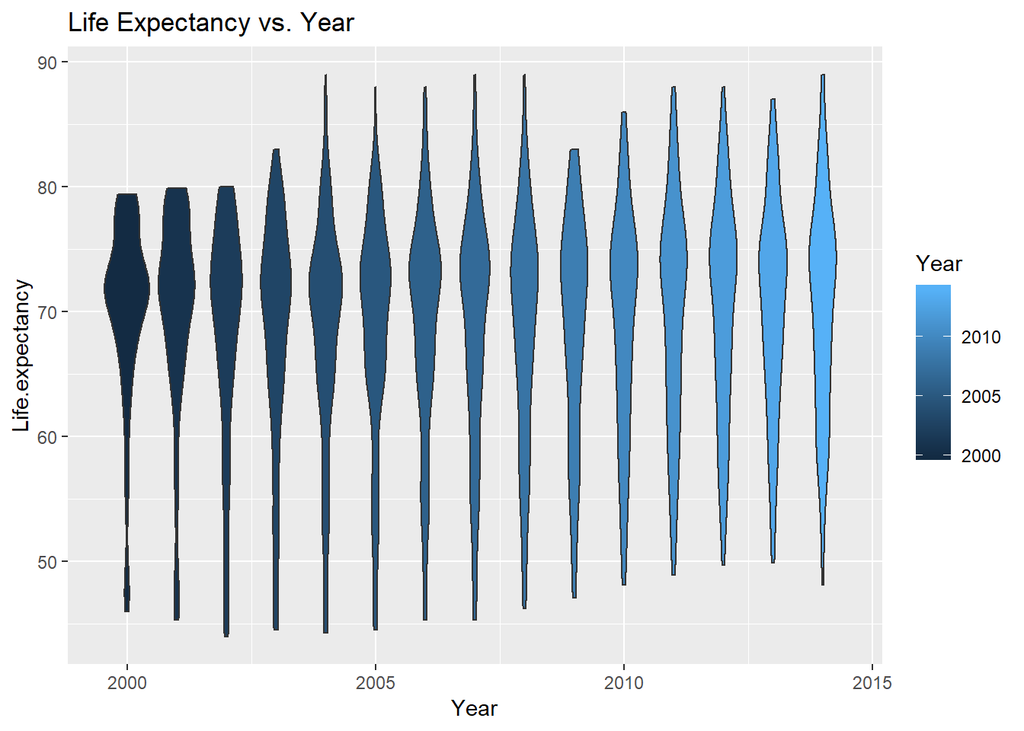

```r
# Violin plot of Life Expectancy vs. Year
data %>% ggplot() + geom_violin(aes(x=Year, y=Life.expectancy, group=Year, fill=Year)) + labs(title = "Life Expectancy vs. Year")
```

### Colinearity

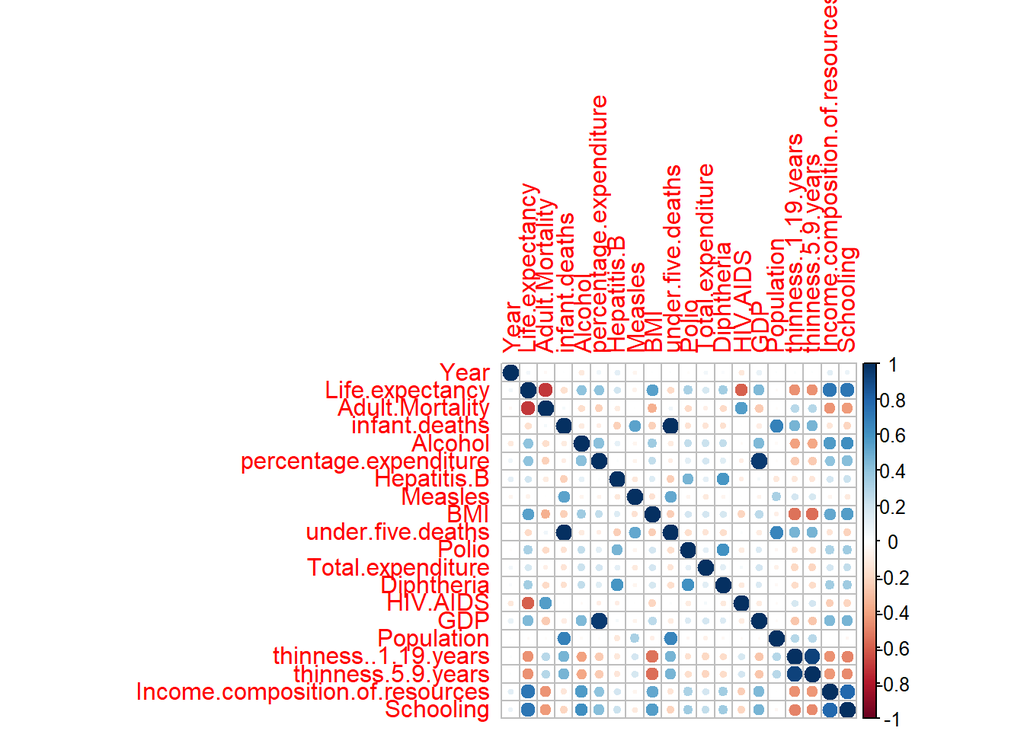

```r
corrplot(cor(data[-c(2)]), method = "circle")
```

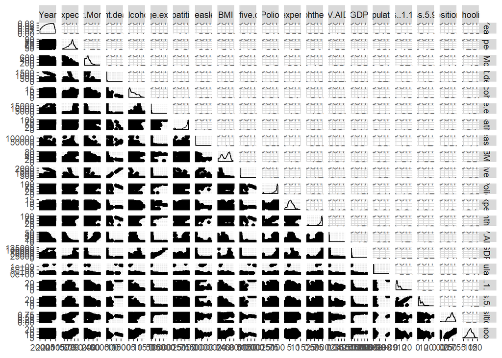

```r
ggpairs(data[-c(2)])
```

```r
round(cor(data[-c(2)]),2)
```

```
##                                  Year Life.expectancy Adult.Mortality
## Year                             1.00            0.05           -0.04
## Life.expectancy                  0.05            1.00           -0.70
## Adult.Mortality                 -0.04           -0.70            1.00
## infant.deaths                    0.01           -0.17            0.04
## Alcohol                         -0.11            0.40           -0.18
## percentage.expenditure           0.07            0.41           -0.24
## Hepatitis.B                      0.11            0.20           -0.11
## Measles                         -0.05           -0.07            0.00
## BMI                              0.01            0.54           -0.35
## under.five.deaths                0.01           -0.19            0.06
## Polio                           -0.02            0.33           -0.20
## Total.expenditure                0.06            0.17           -0.09
## Diphtheria                       0.03            0.34           -0.19
## HIV.AIDS                        -0.12           -0.59            0.55
## GDP                              0.10            0.44           -0.26
## Population                       0.01           -0.02           -0.02
## thinness..1.19.years             0.02           -0.46            0.27
## thinness.5.9.years               0.01           -0.46            0.29
## Income.composition.of.resources  0.12            0.72           -0.44
## Schooling                        0.09            0.73           -0.42
##                                 infant.deaths Alcohol percentage.expenditure
## Year                                     0.01   -0.11                   0.07
## Life.expectancy                         -0.17    0.40                   0.41
## Adult.Mortality                          0.04   -0.18                  -0.24
## infant.deaths                            1.00   -0.11                  -0.09
## Alcohol                                 -0.11    1.00                   0.42
## percentage.expenditure                  -0.09    0.42                   1.00
## Hepatitis.B                             -0.23    0.11                   0.02
## Measles                                  0.53   -0.05                  -0.06
## BMI                                     -0.23    0.35                   0.24
## under.five.deaths                        1.00   -0.10                  -0.09
## Polio                                   -0.16    0.24                   0.13
## Total.expenditure                       -0.15    0.21                   0.18
## Diphtheria                              -0.16    0.24                   0.13
## HIV.AIDS                                 0.01   -0.03                  -0.10
## GDP                                     -0.10    0.44                   0.96
## Population                               0.67   -0.03                  -0.02
## thinness..1.19.years                     0.46   -0.40                  -0.26
## thinness.5.9.years                       0.46   -0.39                  -0.26
```

[output cut: 92 more lines]

```
## percentage.expenditure                                     0.40      0.42
## Hepatitis.B                                                0.18      0.22
## Measles                                                   -0.06     -0.12
## BMI                                                        0.51      0.55
## under.five.deaths                                         -0.15     -0.23
## Polio                                                      0.31      0.35
## Total.expenditure                                          0.18      0.24
## Diphtheria                                                 0.34      0.35
## HIV.AIDS                                                  -0.25     -0.21
## GDP                                                        0.45      0.47
## Population                                                -0.01     -0.04
## thinness..1.19.years                                      -0.45     -0.49
## thinness.5.9.years                                        -0.44     -0.47
## Income.composition.of.resources                            1.00      0.78
## Schooling                                                  0.78      1.00
```

```r
# train test split 70/30 hold out
train_size = floor(0.7 * nrow(data))
train_idx = sample(nrow(data), train_size)
data.train = data[train_idx, ]
data.test = data[-train_idx, ]


model.additive = lm(Life.expectancy ~ ., data.train)
cv.lm(data.train, model.additive, m = 5, plotit = FALSE)
```

```
## Analysis of Variance Table
##
## Response: Life.expectancy
##                                   Df Sum Sq Mean Sq F value  Pr(>F)
## Year                               1    354     354   27.57 1.8e-07 ***
## Status                             1  18975   18975 1475.47 < 2e-16 ***
## Adult.Mortality                    1  32678   32678 2541.02 < 2e-16 ***
## infant.deaths                      1   1056    1056   82.09 < 2e-16 ***
## Alcohol                            1   2680    2680  208.42 < 2e-16 ***
## percentage.expenditure             1   1144    1144   89.00 < 2e-16 ***
## Hepatitis.B                        1    366     366   28.43 1.2e-07 ***
## Measles                            1     54      54    4.23    0.04 *
## BMI                                1   3707    3707  288.25 < 2e-16 ***
## under.five.deaths                  1   1547    1547  120.30 < 2e-16 ***
## Polio                              1    451     451   35.08 4.2e-09 ***
## Total.expenditure                  1     11      11    0.84    0.36
## Diphtheria                         1    205     205   15.97 6.9e-05 ***
## HIV.AIDS                           1   6829    6829  530.99 < 2e-16 ***
## GDP                                1    279     279   21.67 3.6e-06 ***
## Population                         1     27      27    2.10    0.15
## thinness..1.19.years               1    210     210   16.36 5.6e-05 ***
## thinness.5.9.years                 1     32      32    2.48    0.12
## Income.composition.of.resources    1   4658    4658  362.20 < 2e-16 ***
## Schooling                          1   1816    1816  141.25 < 2e-16 ***
## Residuals                       1133  14570      13
## ---
## Signif. codes:  0 '***' 0.001 '**' 0.01 '*' 0.05 '.' 0.1 ' ' 1
##
##
## fold 1
## Observations in test set: 230
##                     139  1345   338   1216   884   391   1754  2910   246  1031
## Predicted       79.2637 74.47 68.29 67.209 60.88 74.61 71.870 61.85 78.04 80.03
## cvpred          79.3677 74.45 68.22 67.132 60.75 74.92 71.999 61.61 78.08 79.64
## Life.expectancy 79.4000 71.90 65.10 66.700 64.20 73.20 72.800 59.20 80.00 85.00
## CV residual      0.0323 -2.55 -3.12 -0.432  3.45 -1.72  0.801 -2.41  1.92  5.36
##                   489  1153   462  2407  1067  2745   198    85  1474     573
## Predicted       56.00 67.94 69.13 52.45 68.03 71.57 65.47 77.92 67.93 72.9944
## cvpred          56.14 68.06 69.08 52.74 68.21 71.81 65.63 77.13 66.74 73.0562
## Life.expectancy 53.60 71.30 77.00 54.90 75.00 67.70 69.90 75.70 72.70 73.1000
```

[output cut: 592 more lines]

```
## Predicted       65.09 70.44 69.80 74.13 63.789 73.40 69.90 73.178 75.78 58.132
## cvpred          64.87 70.08 69.81 74.35 63.629 73.81 70.07 73.462 76.19 58.109
## Life.expectancy 63.50 76.00 73.70 73.00 63.000 72.90 73.90 73.000 74.20 57.600
## CV residual     -1.37  5.92  3.89 -1.35 -0.629 -0.91  3.83 -0.462 -1.99 -0.509
##                   109
## Predicted       70.90
## cvpred          71.15
## Life.expectancy 72.70
## CV residual      1.55
##
## Sum of squares = 2736    Mean square = 11.8    n = 231
##
## Overall (Sum over all 231 folds)
##   ms
## 13.3
```

```r
mean((data.test$Life.expectancy - predict(model.additive, data.test)) ^ 2)
```

```
## [1] 12.3
```

```r
model.selected = step(lm(Life.expectancy ~ ., data.train), trace = FALSE)
cv.lm(data.train, model.selected, m = 5, plotit = FALSE)
```

```
## Analysis of Variance Table
##
## Response: Life.expectancy
##                                   Df Sum Sq Mean Sq F value  Pr(>F)
## Year                               1    354     354   27.62 1.8e-07 ***
## Status                             1  18975   18975 1478.27 < 2e-16 ***
## Adult.Mortality                    1  32678   32678 2545.85 < 2e-16 ***
## infant.deaths                      1   1056    1056   82.25 < 2e-16 ***
## Alcohol                            1   2680    2680  208.81 < 2e-16 ***
## percentage.expenditure             1   1144    1144   89.16 < 2e-16 ***
## BMI                                1   3780    3780  294.50 < 2e-16 ***
## under.five.deaths                  1   1771    1771  138.01 < 2e-16 ***
## Total.expenditure                  1     27      27    2.07    0.15
## Diphtheria                         1    593     593   46.21 1.7e-11 ***
## HIV.AIDS                           1   6807    6807  530.30 < 2e-16 ***
## Income.composition.of.resources    1   5208    5208  405.75 < 2e-16 ***
## Schooling                          1   1944    1944  151.44 < 2e-16 ***
## Residuals                       1140  14633      13
## ---
## Signif. codes:  0 '***' 0.001 '**' 0.01 '*' 0.05 '.' 0.1 ' ' 1
##
##
## fold 1
## Observations in test set: 230
##                     139  1345   338  1216   884   391   1754  2910   246  1031
## Predicted       79.3519 74.54 68.28 67.73 60.59 74.66 71.924 62.27 78.12 79.96
## cvpred          79.4837 74.51 68.27 67.94 60.36 74.96 72.066 62.01 78.25 79.61
## Life.expectancy 79.4000 71.90 65.10 66.70 64.20 73.20 72.800 59.20 80.00 85.00
## CV residual     -0.0837 -2.61 -3.17 -1.24  3.84 -1.76  0.734 -2.81  1.75  5.39
##                  489  1153   462  2407 1067  2745   198    85  1474  573  2846
## Predicted       55.9 67.82 68.89 53.29 67.9 71.32 65.88 77.72 67.87 73.3 67.18
## cvpred          56.1 67.96 68.74 53.29 68.1 71.35 66.05 76.89 66.72 74.2 66.99
## Life.expectancy 53.6 71.30 77.00 54.90 75.0 67.70 69.90 75.70 72.70 73.1 71.40
## CV residual     -2.5  3.34  8.26  1.61  6.9 -3.65  3.85 -1.19  5.98 -1.1  4.41
##                   679  1608   562    89  2009   998   1738  2732     31   1374
## Predicted       77.42 71.00 73.65 76.98 73.38 77.49 75.637 73.19 72.894 53.533
## cvpred          77.62 70.81 73.97 76.67 73.33 77.11 75.487 72.56 73.047 53.453
## Life.expectancy 79.50 76.70 75.80 74.80 75.30 86.00 75.300 78.00 73.600 53.000
## CV residual      1.88  5.89  1.83 -1.87  1.97  8.89 -0.187  5.44  0.553 -0.453
##                  2453  1024   800   936  2436  1023   761   262   2221   785
```

[output cut: 585 more lines]

```
## Predicted       52.0 72.46 62.50 70.0 71.122 80.33 63.9 83.36 64.284 59.5 65.52
## cvpred          52.1 72.62 62.42 70.1 71.055 80.56 64.0 83.45 64.184 59.4 65.28
## Life.expectancy 54.0 74.60 56.80 72.4 71.400 77.20 66.4 80.00 64.600 57.0 63.50
## CV residual      1.9  1.98 -5.62  2.3  0.345 -3.36  2.4 -3.45  0.416 -2.4 -1.78
##                  2654  2547  2637   1802  2681  1143    832  2676  2161   109
## Predicted       70.17 69.86 74.09 63.677 73.53 69.84 73.153 75.97 58.10 70.82
## cvpred          69.79 69.77 74.35 63.545 73.91 70.04 73.451 76.35 57.99 71.06
## Life.expectancy 76.00 73.70 73.00 63.000 72.90 73.90 73.000 74.20 57.60 72.70
## CV residual      6.21  3.93 -1.35 -0.545 -1.01  3.86 -0.451 -2.15 -0.39  1.64
##
## Sum of squares = 2716    Mean square = 11.8    n = 231
##
## Overall (Sum over all 231 folds)
##   ms
## 13.2
```

```r
mean((data.test$Life.expectancy - predict(model.selected, data.test)) ^ 2)
```

```
## [1] 12.3
```

VIF for the additive model

```r
vif(model.additive)
```

```
##                            Year                StatusDeveloping
##                            1.14                            1.89
##                 Adult.Mortality                   infant.deaths
##                            1.83                          241.64
##                         Alcohol          percentage.expenditure
##                            2.39                           12.75
##                     Hepatitis.B                         Measles
##                            1.69                            1.53
##                             BMI               under.five.deaths
##                            1.80                          229.98
##                           Polio               Total.expenditure
##                            1.85                            1.16
##                      Diphtheria                        HIV.AIDS
##                            2.10                            1.51
##                             GDP                      Population
##                           13.44                            1.86
##            thinness..1.19.years              thinness.5.9.years
##                            8.87                            8.79
## Income.composition.of.resources                       Schooling
##                            2.97                            3.59
```

```r
which(vif(model.additive) > 5)
```

```
##          infant.deaths percentage.expenditure      under.five.deaths
##                      4                      6                     10
##                    GDP   thinness..1.19.years     thinness.5.9.years
##                     15                     17                     18
```

```r
vif(model.selected)
```

```
##                            Year                StatusDeveloping
##                            1.10                            1.87
##                 Adult.Mortality                   infant.deaths
##                            1.81                          202.39
##                         Alcohol          percentage.expenditure
##                            2.34                            1.42
##                             BMI               under.five.deaths
##                            1.55                          203.48
##               Total.expenditure                      Diphtheria
##                            1.14                            1.18
##                        HIV.AIDS Income.composition.of.resources
##                            1.49                            2.93
##                       Schooling
##                            3.49
```

```r
which(vif(model.selected) > 5)
```

```
##     infant.deaths under.five.deaths
##                 4                 8
```

The selected model efficiently removed some predictors which have colinearity issues, but not all. We can see infant.deaths and under.five.deaths are still co-exist in the selected model.

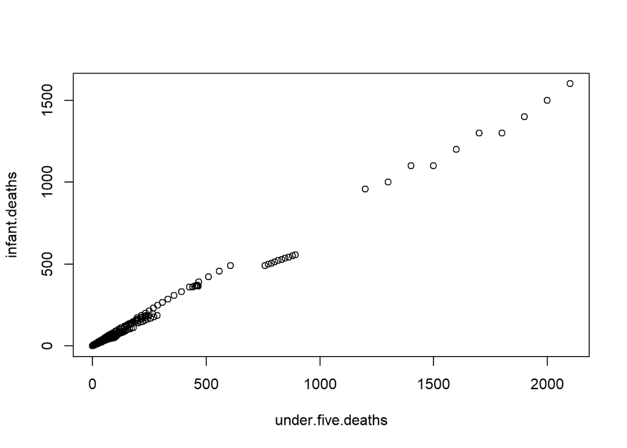

```r
plot(infant.deaths ~ under.five.deaths, data = data)
```

### Model Building

```r
# train test split 70/30 hold out
set.seed(42)
train_size = floor(0.7 * nrow(data))
train_idx = sample(nrow(data), train_size)
data_trn = data[train_idx, ]
data_tst = data[-train_idx, ]
```

```r
# Define functions
calc_loocv_rmse = function(model) {
  c("LOOCV_RMSE:",sqrt(mean((resid(model) / (1 - hatvalues(model))) ^ 2)))
}

calc_bp = function(model) {
  c("BP test:", unname(bptest(model)$p.value))
}

calc_shapiro = function(model) {
  c("Shapiro test:", unname(shapiro.test(resid(model))$p.value))
}

calc_adj_r2 = function(model) {
  c("Adj.R2:", summary(model)$adj.r.squared)
}
```

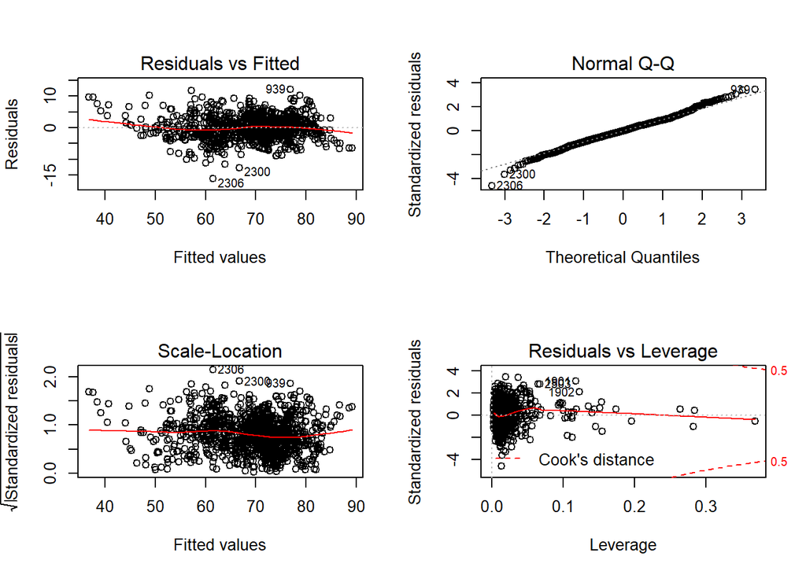

```r
# Model_1, basic additive model with all the parameters
model_1 = lm(Life.expectancy ~ ., data_trn)
par(mfrow=c(2,2))
plot(model_1)
```

```r
calc_bp(model_1)
```

```
## [1] "BP test:"             "1.06753304313199e-18"
```

```r
calc_shapiro(model_1)
```

```
## [1] "Shapiro test:"        "0.000142390687235932"
```

```r
calc_loocv_rmse(model_1)
```

```
## [1] "LOOCV_RMSE:"      "3.58422898173348"
```

```r
calc_adj_r2(model_1)
```

```
## [1] "Adj.R2:"           "0.831530797195294"
```

```r
# Model_2, backward AIC on additive model
model_2 = step(model_1, trace = FALSE)
coef(model_2)
```

```
##                     (Intercept)                            Year
##                        286.6524                         -0.1166
##                StatusDeveloping                 Adult.Mortality
##                         -0.7627                         -0.0148
##                   infant.deaths                         Alcohol
##                          0.0793                         -0.1400
##          percentage.expenditure                             BMI
##                          0.0005                          0.0338
##               under.five.deaths                           Polio
##                         -0.0597                          0.0108
##               Total.expenditure                      Diphtheria
##                          0.1513                          0.0136
##                        HIV.AIDS            thinness..1.19.years
##                         -0.4572                         -0.0626
## Income.composition.of.resources                       Schooling
##                         10.6011                          0.8706
```

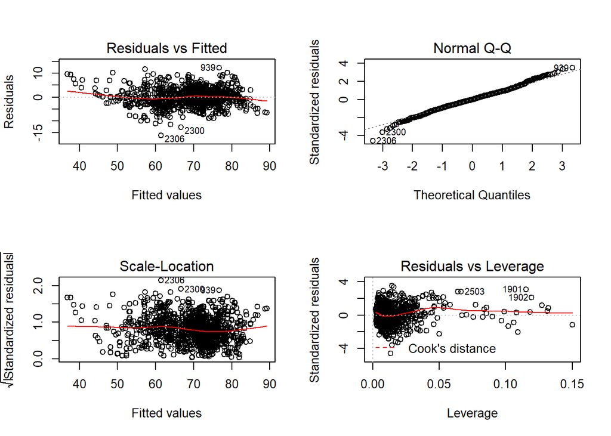

```r
par(mfrow=c(2,2))
plot(model_2)
```

```r
calc_bp(model_2)
```

```
## [1] "BP test:"             "5.89766168948721e-20"
```

```r
calc_shapiro(model_2)
```

```
## [1] "Shapiro test:"        "0.000152257737050676"
```

```r
calc_loocv_rmse(model_2)
```

```
## [1] "LOOCV_RMSE:"      "3.57398562547131"
```

```r
calc_adj_r2(model_2)
```

```
## [1] "Adj.R2:"           "0.832143041393922"
```

```r
# Model_3, backward BIC on additive model
n = length(resid(model_1))
model_3 = step(model_1, k = log(n), trace = FALSE)
coef(model_3)
```

```
##                     (Intercept)                            Year
##                       299.26327                        -0.12352
##                 Adult.Mortality                   infant.deaths
##                        -0.01516                         0.07874
##                         Alcohol          percentage.expenditure
##                        -0.09713                         0.00053
##                             BMI               under.five.deaths
##                         0.03721                        -0.06008
##               Total.expenditure                      Diphtheria
##                         0.16017                         0.01873
##                        HIV.AIDS Income.composition.of.resources
##                        -0.46262                        10.77947
##                       Schooling
##                         0.90100
```

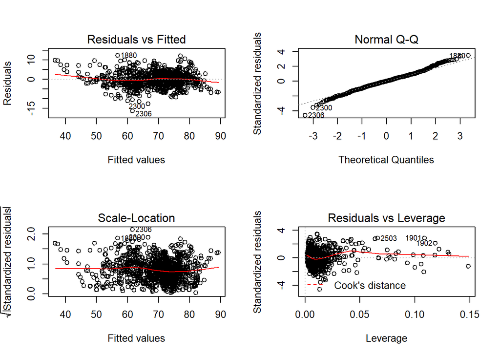

```r
par(mfrow=c(2,2))
plot(model_3)
```

```r
calc_bp(model_3)
```

```
## [1] "BP test:"             "4.75415871100533e-22"
```

```r
calc_shapiro(model_3)
```

```
## [1] "Shapiro test:"         "0.0000389851564983809"
```

```r
calc_loocv_rmse(model_3)
```

```
## [1] "LOOCV_RMSE:"      "3.58063093482768"
```

```r
calc_adj_r2(model_3)
```

```
## [1] "Adj.R2:"           "0.831059196901044"
```

We can see that no big improvement on AIC and BIC results based on the additive model.

Next, we will start with the interactive model.

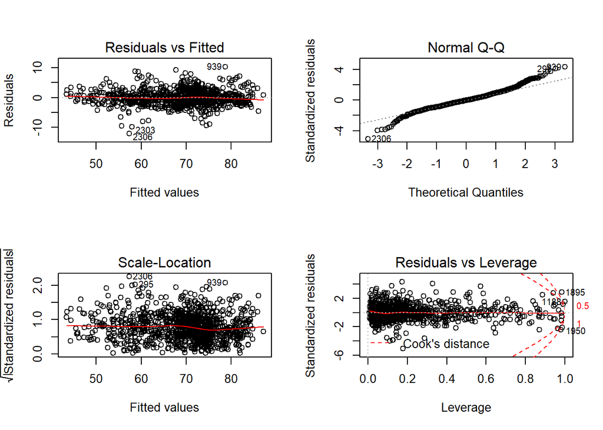

```r
# Model_4, basic interactive model with all the parameters
model_4 = lm(Life.expectancy ~ . ^ 2, data_trn)
par(mfrow=c(2,2))
plot(model_4)
```

```r
calc_bp(model_4)
```

```
## [1] "BP test:"           "0.0350257273124796"
```

```r
calc_shapiro(model_4)
```

```
## [1] "Shapiro test:"        "2.00075047432031e-14"
```

```r
calc_loocv_rmse(model_4)
```

```
## [1] "LOOCV_RMSE:"      "6.32632579517486"
```

```r
calc_adj_r2(model_4)
```

```
## [1] "Adj.R2:"           "0.907962924404157"
```

```r
length(coef(model_4))
```

```
## [1] 211
```

We can see that the interactive model using all the predictors turns out really big and there are 211 parameters in the model. We will focus on the parameters that are selected by Model_2 and apply AIC on the interactive model based on those parameters.

```r
# Model_5, interactive model based on Model_2
# under.five.deaths is excluded because the colinearity issue with infant.deanths parameters
coef(model_2)
```

```
##                     (Intercept)                            Year
##                        286.6524                         -0.1166
##                StatusDeveloping                 Adult.Mortality
##                         -0.7627                         -0.0148
##                   infant.deaths                         Alcohol
##                          0.0793                         -0.1400
##          percentage.expenditure                             BMI
##                          0.0005                          0.0338
##               under.five.deaths                           Polio
##                         -0.0597                          0.0108
##               Total.expenditure                      Diphtheria
##                          0.1513                          0.0136
##                        HIV.AIDS            thinness..1.19.years
##                         -0.4572                         -0.0626
## Income.composition.of.resources                       Schooling
##                         10.6011                          0.8706
```

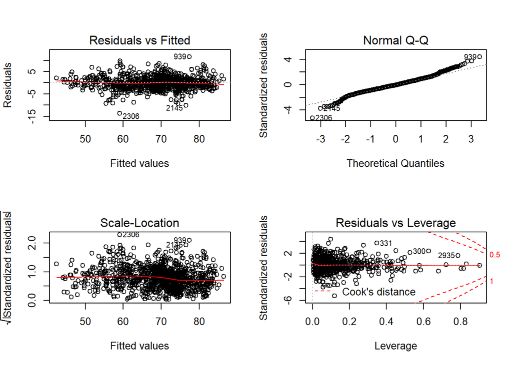

```r
model_5 = lm(Life.expectancy ~ (Year + Status + Adult.Mortality + infant.deaths + Alcohol + percentage.expenditure + BMI + Polio + Total.expenditure
                                + Diphtheria + HIV.AIDS + thinness..1.19.years + Income.composition.of.resources + Schooling) ^ 2, data = data_trn)
par(mfrow=c(2,2))
plot(model_5)
```

```r
calc_bp(model_5)
```

```
## [1] "BP test:"            "4.1462009319212e-07"
```

```r
calc_shapiro(model_5)
```

```
## [1] "Shapiro test:"        "3.83717678229168e-11"
```

```r
calc_loocv_rmse(model_5)
```

```
## [1] "LOOCV_RMSE:"      "3.00964718488528"
```

```r
calc_adj_r2(model_5)
```

```
## [1] "Adj.R2:"           "0.895169999246715"
```

```r
length(coef(model_5))
```

```
## [1] 106
```

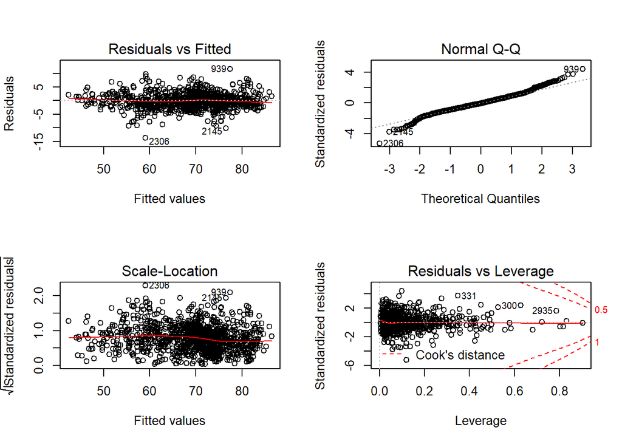

```r
# Model_6, backward AIC on interactive model
model_6 = step(model_5, trace = FALSE)
par(mfrow=c(2,2))
plot(model_5)
```

```r
calc_bp(model_5)
```

```
## [1] "BP test:"            "4.1462009319212e-07"
```

```r
calc_shapiro(model_5)
```

```
## [1] "Shapiro test:"        "3.83717678229168e-11"
```

```r
calc_loocv_rmse(model_5)
```

```
## [1] "LOOCV_RMSE:"      "3.00964718488528"
```

```r
calc_adj_r2(model_5)
```

```
## [1] "Adj.R2:"           "0.895169999246715"
```

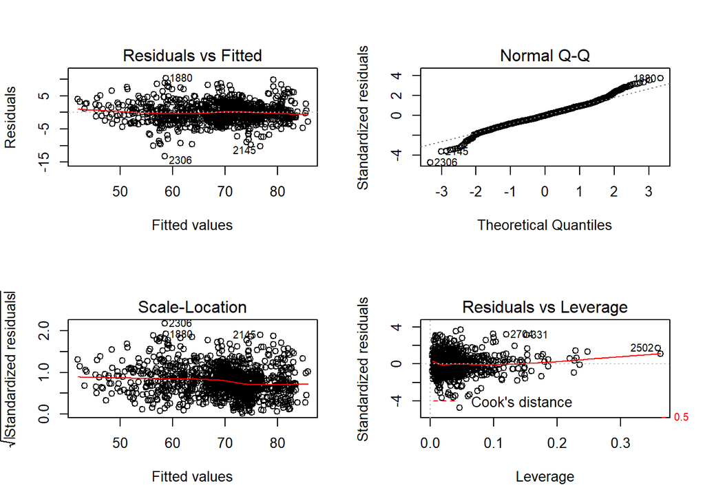

```r
# Model_7, backward BIC on interactive model
n = length(resid(model_5))
model_7 = step(model_5, k = log(n), trace = FALSE)
par(mfrow=c(2,2))
plot(model_7)
```

```r
calc_bp(model_7)
```

```
## [1] "BP test:"             "6.43673809602792e-12"
```

```r
calc_shapiro(model_7)
```

```
## [1] "Shapiro test:"       "1.3729812233272e-10"
```

```r
calc_loocv_rmse(model_7)
```

```
## [1] "LOOCV_RMSE:"      "2.92111619240649"
```

```r
calc_adj_r2(model_7)
```

```
## [1] "Adj.R2:"           "0.890358899035256"
```

We can see that model_7 still have 39 parameters. To simply the model, we can use p-value < 0.0001 to filter predictors. We will also add second order predictors and use AIC/BIC to further reduce model.

```r
length(coef(model_7))
```

```
## [1] 39
```

```r
which(summary(model_7)$coefficients[,4] < 0.0001)
```

```
##                                   Adult.Mortality
##                                                 4
##                                               BMI
##                                                 8
##                                        Diphtheria
##                                                11
##                              thinness..1.19.years
##                                                13
##                   Income.composition.of.resources
##                                                14
##                                         Schooling
##                                                15
##              Year:Income.composition.of.resources
##                                                18
##                                    Year:Schooling
##                                                19
##                  StatusDeveloping:Adult.Mortality
##                                                20
##             StatusDeveloping:thinness..1.19.years
##                                                22
##                         Adult.Mortality:Schooling
##                                                25
##     infant.deaths:Income.composition.of.resources
##                                                26
##                           infant.deaths:Schooling
##                                                27
##                         Alcohol:Total.expenditure
##                                                28
##                                  Alcohol:HIV.AIDS
##                                                29
##           Alcohol:Income.composition.of.resources
##                                                31
##                                    BMI:Diphtheria
##                                                33
##               BMI:Income.composition.of.resources
##                                                34
##                                     BMI:Schooling
##                                                35
## Total.expenditure:Income.composition.of.resources
##                                                38
```

```r
model_8 = lm(Life.expectancy ~ Adult.Mortality + BMI + Diphtheria + thinness..1.19.years + Income.composition.of.resources + Schooling +  Year:Income.composition.of.resources + Year:Schooling + Status:Adult.Mortality + Status:thinness..1.19.years + Adult.Mortality:Schooling + infant.deaths:Income.composition.of.resources + infant.deaths:Schooling + Alcohol:Total.expenditure + Alcohol:HIV.AIDS + Alcohol:Income.composition.of.resources + BMI:Diphtheria + BMI:Income.composition.of.resources + BMI:Schooling + Total.expenditure:Income.composition.of.resources + I(Adult.Mortality^2) + I(BMI^2) + I(Diphtheria^2) + I(thinness..1.19.years^2) + I(Income.composition.of.resources^2) + I(Schooling^2), data = data_trn)
length(coef(model_8))
```

```
## [1] 27
```

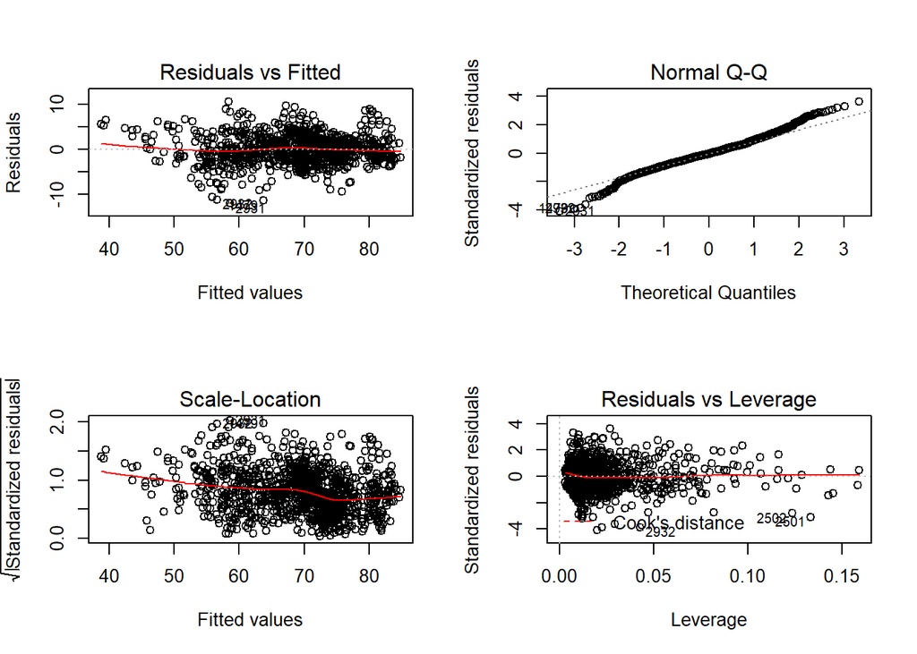

```r
# Model_9, backward AIC on reduced model
model_9 = step(model_8, trace = FALSE)
par(mfrow=c(2,2))
plot(model_9)
```

```r
calc_bp(model_9)
```

```
## [1] "BP test:"             "1.25586859508963e-17"
```

```r
calc_shapiro(model_9)
```

```
## [1] "Shapiro test:"        "1.43501270267459e-09"
```

```r
calc_loocv_rmse(model_9)
```

```
## [1] "LOOCV_RMSE:"      "3.01869412852157"
```

```r
calc_adj_r2(model_9)
```

```
## [1] "Adj.R2:"           "0.881224986529788"
```

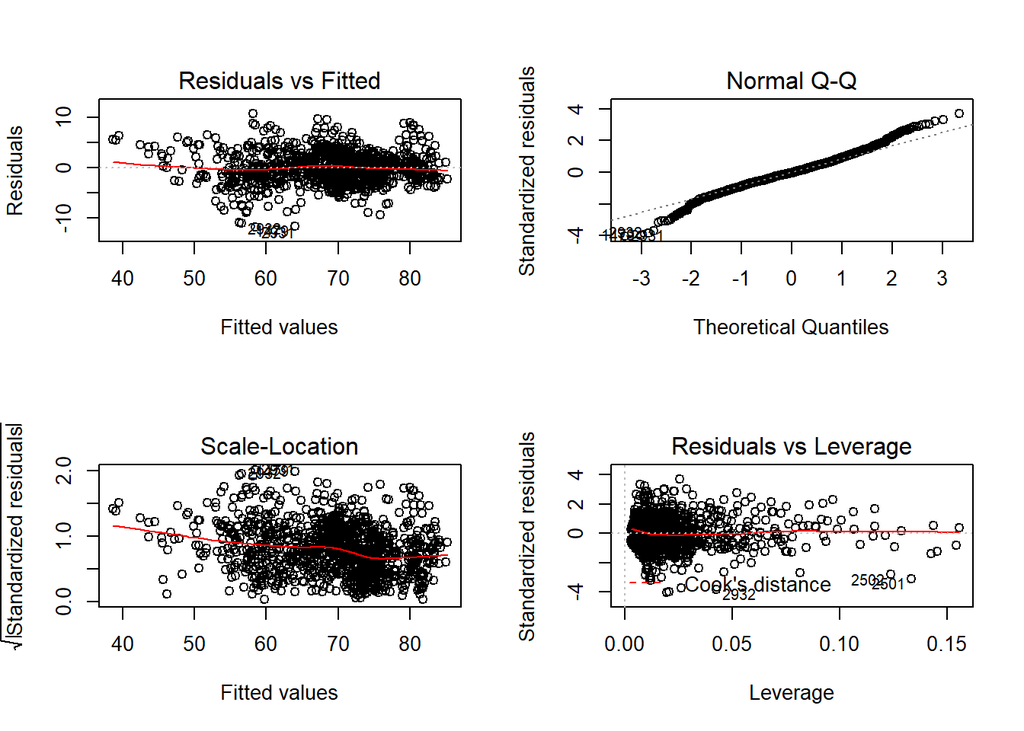

```r
# Model_10, backward BIC on reduced model
n = length(resid(model_8))
model_10 = step(model_8, k = log(n), trace = FALSE)
par(mfrow=c(2,2))
plot(model_10)
```

```r
calc_bp(model_10)
```

```
## [1] "BP test:"             "2.86982827390071e-17"
```

```r
calc_shapiro(model_10)
```

```
## [1] "Shapiro test:"        "2.48317788164929e-09"
```

```r
calc_loocv_rmse(model_10)
```

```
## [1] "LOOCV_RMSE:"      "3.02059894996611"
```

```r
calc_adj_r2(model_10)
```

```
## [1] "Adj.R2:"           "0.880949043095113"
```

```r
length(coef(model_10))
```

```
## [1] 24
```

There are still 24 parameters after BIC step.

Change strategy, use the first order predictors in model_8 to build the interactive and second order models and apply AIC/BIC on it.

```r
model_11 = lm(Life.expectancy ~ (Adult.Mortality + BMI + Diphtheria + thinness..1.19.years + Income.composition.of.resources + Schooling) ^ 2 + I(Adult.Mortality^2) + I(BMI^2) + I(Diphtheria^2) + I(thinness..1.19.years^2) + I(Income.composition.of.resources^2) + I(Schooling^2), data = data_trn)
length(coef(model_11))
```

```
## [1] 28
```

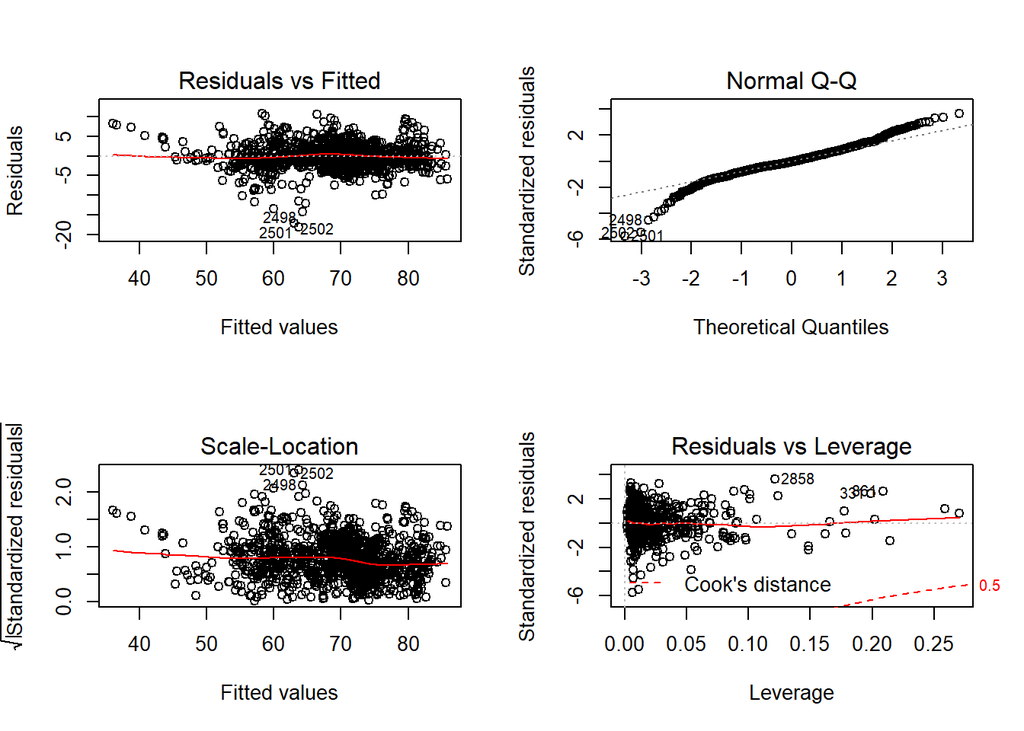

```r
# Model_12, backward AIC on reduced model_11
model_12 = step(model_11, trace = FALSE)
par(mfrow=c(2,2))
plot(model_12)
```

```r
calc_bp(model_12)
```

```
## [1] "BP test:"             "9.32569415279849e-16"
```

```r
calc_shapiro(model_12)
```

```
## [1] "Shapiro test:"       "6.9418924612486e-16"
```

```r
calc_loocv_rmse(model_12)
```

```
## [1] "LOOCV_RMSE:"      "3.20536581835464"
```

```r
calc_adj_r2(model_12)
```

```
## [1] "Adj.R2:"           "0.866503456987311"
```

```r
length(coef(model_12))
```

```
## [1] 20
```

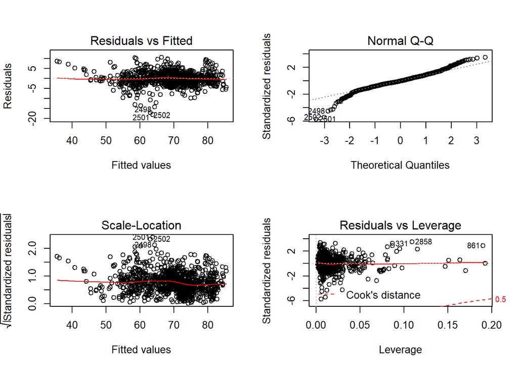

```r
# Model_13, backward BIC on reduced model_11
n = length(resid(model_11))
model_13 = step(model_11, k = log(n), trace = FALSE)
par(mfrow=c(2,2))
plot(model_13)
```

```r
calc_bp(model_13)
```

```
## [1] "BP test:"             "1.38613074491302e-18"
```

```r
calc_shapiro(model_13)
```

```
## [1] "Shapiro test:"        "3.08693987626621e-16"
```

```r
calc_loocv_rmse(model_13)
```

```
## [1] "LOOCV_RMSE:"      "3.21577815809087"
```

```r
calc_adj_r2(model_13)
```

```
## [1] "Adj.R2:"          "0.86449056663892"
```

```r
length(coef(model_13))
```

```
## [1] 16
```